# ePlant: Visualizing and Exploring Multiple Levels of Data for Hypothesis Generation in Plant Biology | The Plant Cell | Oxford Academic

### Plant eFP Viewer

The Plant eFP viewer (Figures 2B and 3B) displays the selected gene's expression pattern by dynamically coloring the tissues of a pictographic representation of a plant according to gene expression levels from multiple experiments. This visualization method is known as an electronic fluorescent pictograph (eFP), and it is a reimplementation of the developmental map view of Arabidopsis eFP Browser by Winter et al. (2007).

Several new features have been added. For one, the chart has been redrawn as an SVG image (a vector image instead of a bitmap) and redundant black outlines have been omitted to improve the data/ink ratio (Tufte and Graves-Morris, 1983). Also, since SVG shapes can be filled with any color programmatically, it is now possible to adjust color gradients on the fly without having to redownload the image. This makes it possible to toggle between absolute and relative views with almost no latency between screen updates. Finally, expression patterns for several dozen genes occupy much less bandwidth than separate image files for each gene. This makes it possible to switch between eFP images for multiple genes at intervals of 150 ms or faster, a technique known as rapid serial visual presentation (RSVP), discussed later in this article.

Figures 2B and 3B show the spatio-temporal distribution of *ABI3* gene expression levels across the various developmental stages of Arabidopsis based on data from Schmid et al. (2005) and Nakabayashi et al. (2005). With a single glance, it is possible to see that *ABI3* has a narrow expression pattern that is limited to the maturing seeds.

### Tissue and Experiment eFP Viewer

The Tissue and Experiment eFP Viewer (Figure 6) provides detail level information about gene expression in individual tissues and the results of perturbation response experiments. The 22 views in this ePlant module display information for 640 separate tissues based on 1385 samples. Multiplying that by the 22,814 genes on the ATH1 array (RNA-seq data are available in the Sequence Viewer module) produces a data set of 31,597,390 records into which each query taps. This is an example of how big data can be explored with a simple graphical interface.

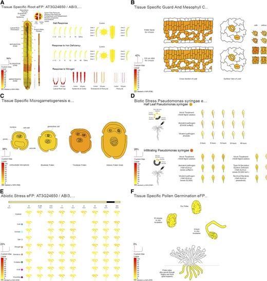

Figure 6.

Six of More Than 20 Views from the Tissue and Experiment eFP Viewer.

Each view displays expression levels for *ABI3* with the “custom” color gradient setting, with red = 100 expression units: root **(A)**, guard and mesophyll cells **(B)**, microgametogenesis **(C)**, biotic stress: *Pseudomonas syringae* **(D)**, abiotic stress **(E)**, and pollen germination **(F)**. Some views are truncated for display here; see online version of the figure to be able to see detail. ePlant outputs for all views may be downloaded as high-resolution vector graphic files and are freely available for use by any researcher under an “open” license.

[Open in new tab](https://academic.oup.com/view-large/figure/234710897/plcell_v29_8_1806_f6.jpeg)Download slide

Many of the views in this module are based on supplemental views that have been added since the original publication of the Arabidopsis eFP Browser (Winter et al., 2007). They have been updated in keeping with current data visualization best practices. Three new features have been added. First, a vertical stack of thumbnail images along the left side of the window provides a visual method for selecting the active view. Second, the thumbnail images can be sorted either alphabetically or by the maximum expression level for each of the views, making it easy to identify which tissues or experimental conditions are associated with high expression levels for the selected gene. Also, simply by glancing at the proportion of red or yellow in the stack of thumbnail images (a visualization technique sometimes referred to as “small multiples”; Tufte, 1990), it is possible to get a Gestalt sense of the expression pattern for the selected gene in various contexts without opening a single view (e.g., *“*Does my gene of interest have a narrow or wide expression pattern?”). Finally, the global color gradient option (discussed in the Heat Map Viewer section above) is especially useful here because it enables viewers to compare spatio-temporal, tissue-specific, and perturbation response expression levels all on the same scale (as in Figure 6). The views represent separate experiments, but they are easily comparable because the results are mapped to a common scale. This makes it possible to quickly answer the question, “In which tissue, and under what circumstance, does my gene of interest have the highest expression”?

As with all the tools in ePlant, the raw data used to generate the charts are available for download as a text file by clicking the “Download Raw Data” button on the toolbar. Table 1 provides a list of all the views available in the Experiment and Tissue eFP Viewer along with their data sources.